# Workshop 3 - Dependency, Relationships and Associations

## Plot symbols

The symbols used for points in scatter plots can be changed by specifying a value for the argument `pch` {#pch} (which stands for **p**lot **ch**aracter). Specifying values for `pch` works in the same way as `col`, though `pch` only accepts integers between 1 and 20 to represent different point types. The default is `pch=1` which is a hollow circle. The possible values of `pch` are shown in the plot below:

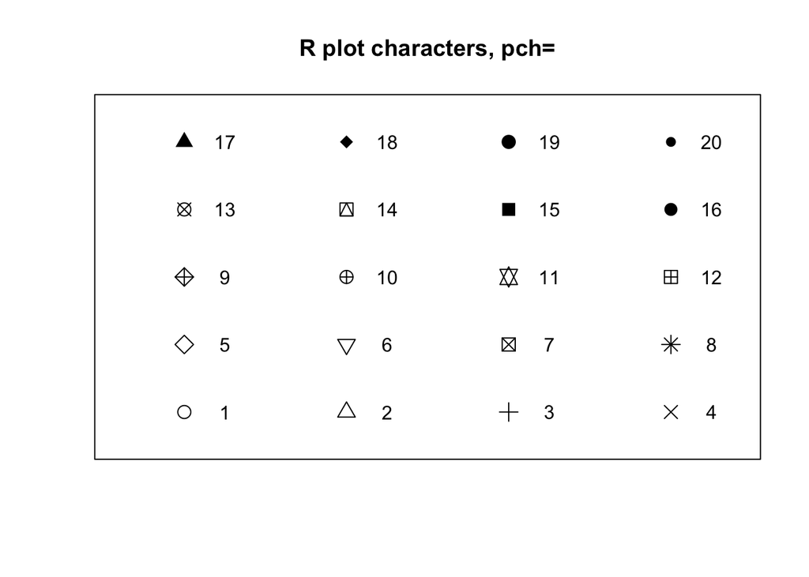

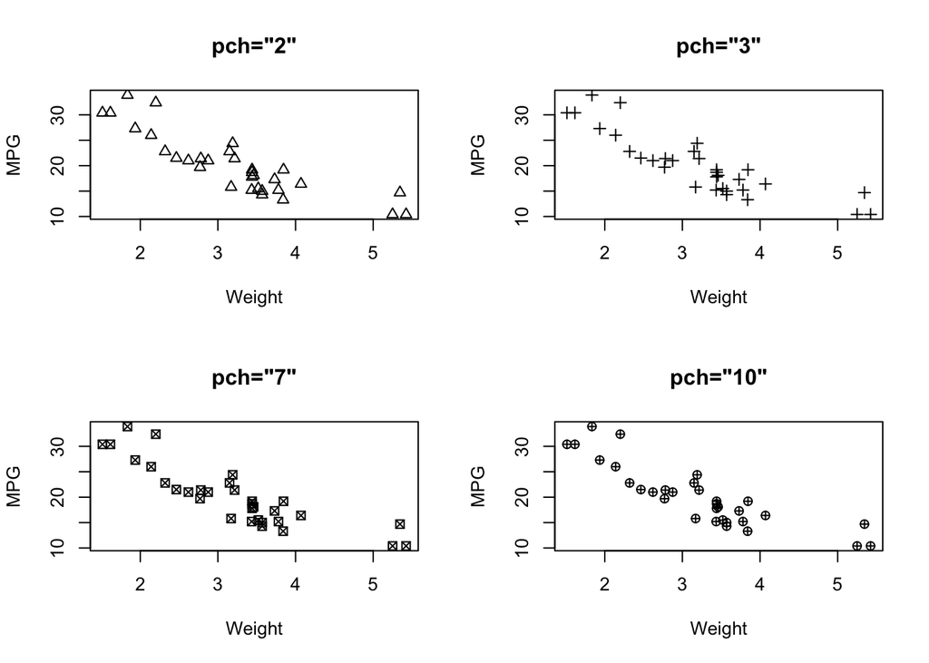

```r
par(mfrow=c(2,2))
plot(x=mtcars$wt, mtcars$mpg, xlab="Weight", ylab="MPG", main='pch="2"', pch=2)
plot(x=mtcars$wt, mtcars$mpg, xlab="Weight", ylab="MPG", main='pch="3"', pch=3)
plot(x=mtcars$wt, mtcars$mpg, xlab="Weight", ylab="MPG", main='pch="7"', pch=7)
plot(x=mtcars$wt, mtcars$mpg, xlab="Weight", ylab="MPG", main='pch="10"', pch=10)
```

## Overplotting and transparency

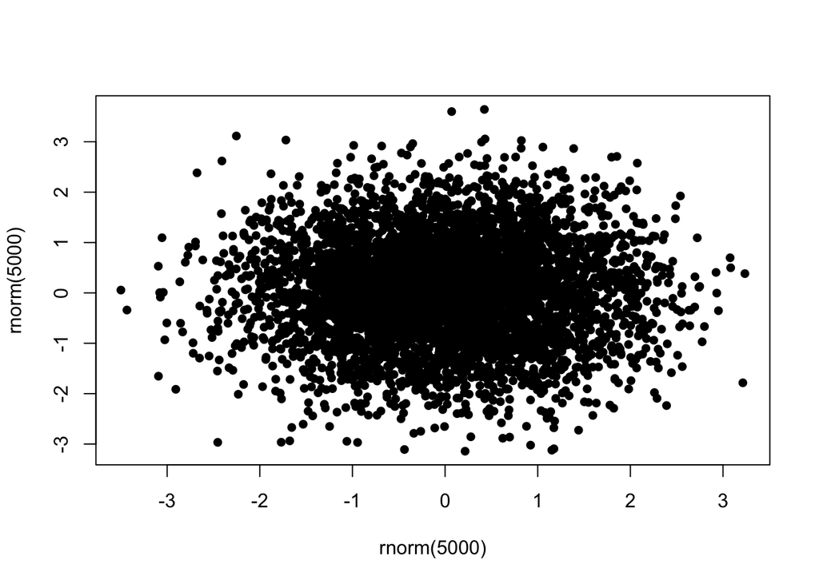

```r
plot(x=rnorm(5000),y=rnorm(5000),pch=16)
```

To ‘fix’ this, we can specify a transparent colour in the `col` argument by using the `alpha` function from the scales package:

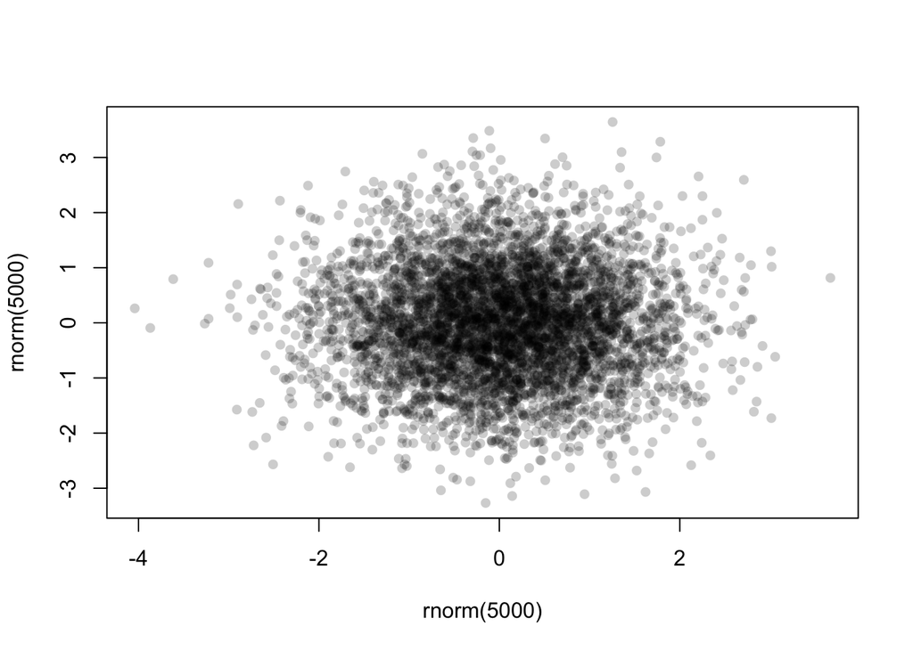

```r
library(scales)
plot(x=rnorm(5000),y=rnorm(5000),pch=16,col=alpha('black',0.2))
```

The `alpha` function takes two arguments - a colour first, and then the `alpha` level itself. This should be a number in $[0,1]$ with smaller values being more transparent. Finding a good value for `alpha` is usually a case of trial-and-error, but in general it will be smaller than you might first expect!

Download data: engine

This rather simple data set contains three numerical variables, each representing different amounts of pollutants emitted by 46 light-duty engines. The pollutants recorded are Carbon monoxide (`CO`), Hydrocarbons (`HC`), and Nitrogen oxide (`NOX`), all recorded as grammes emitted per mile.

## Challenge

- Download the `engine` data set and load it into your workspace
- Construct three scatterplots to investigate the relationships between every pair of pollutants:
  - `CO` versus `HC`
  - `CO` versus `NOX`
  - `HC` versus `NOX`
- What are the relationships between the amounts of different pollutants emitted by the various engines? In particular, which pollutants are positively associated and which are negatively associated?

**Click for solution**

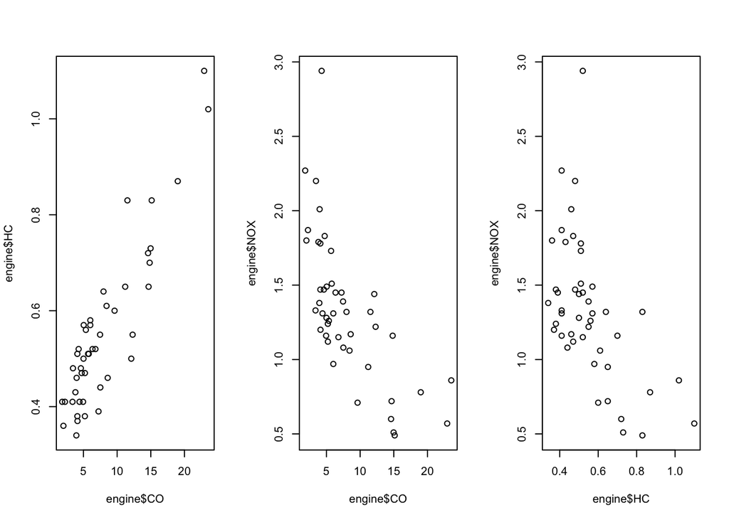

```r
par(mfrow=c(1,3))
plot(x=engine$CO, y=engine$HC)
plot(x=engine$CO, y=engine$NOX)
plot(x=engine$HC, y=engine$NOX)
```

The first plot shows a strong positive linear relationship; The second plot a fairly strong, decreasing non-linear relationship; The third plot a weaker linear relationship.

The correlation between these variables is checked using the `cor` function.

Correlation Matrix

|  | CO | HC | NOX |
| --- | --- | --- | --- |
| CO | 1.00 | 0.90 | -0.69 |
| HC | 0.90 | 1.00 | -0.56 |
| NOX | -0.69 | -0.56 | 1.00 |

The following is code to produce a nice correlation matrix

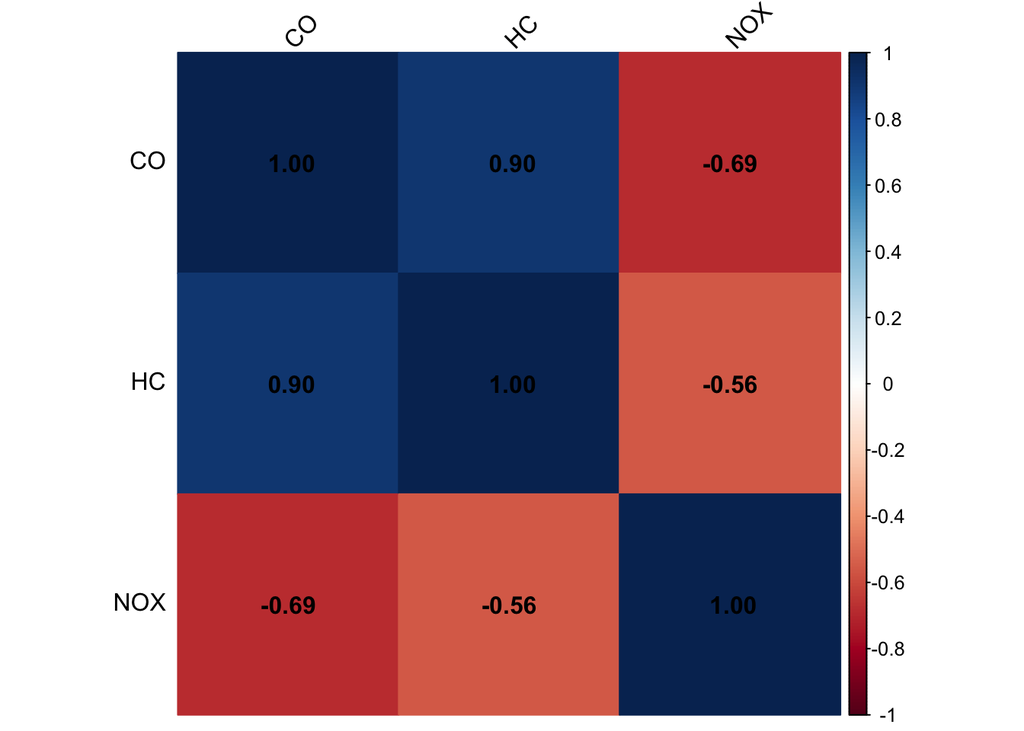

```r
library(corrplot)
cor_matrix <- cor(engine)

corrplot(cor_matrix, method = "color", addCoef.col = "black", tl.col = "black", tl.srt = 45)
```

and a scatterplot matrix can be plotted using the `pairs()` command.

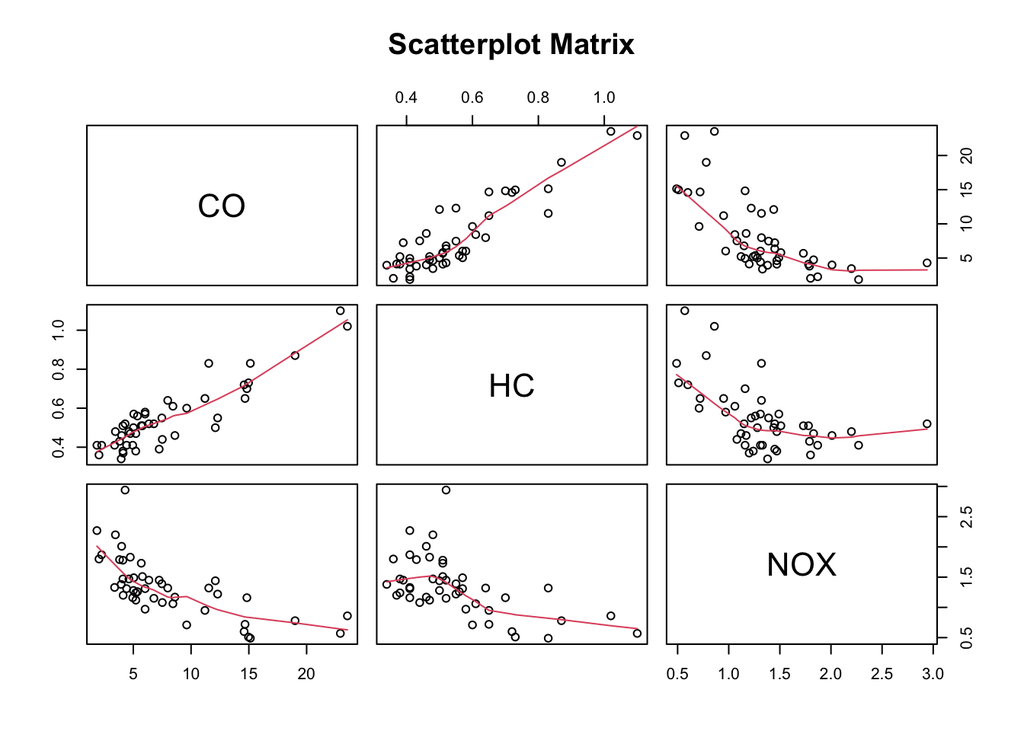

```r
pairs(engine, panel = panel.smooth, main = "Scatterplot Matrix")
```

If you want include correlation coefficients in a scatterplot matrix, you might want to look into the `pairs.panels` command. You need to have the `psych` package installed for this.

```r
library(psych)
```

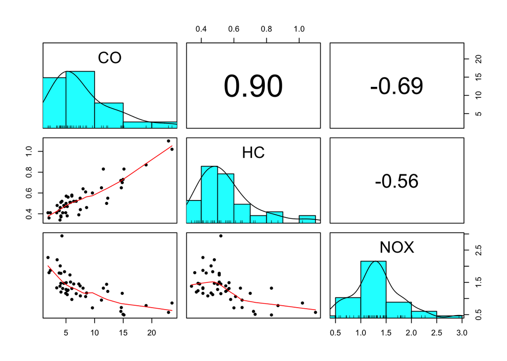

```r
pairs.panels(engine, scale=TRUE, ellipses=FALSE)
```

## Visualizing outliers

Scatterplots are useful at identifying outliers and other distributional features.

Data points can be outliers in two dimensions without being outliers in the separate dimensions! For example taller people are generally heavier, but a particularly heavy person of average height stands out more.

Scatterplots help you determine which points are outliers and if they are outliers in more than one variable.

The scatterplots suggest maybe one large outlier on NOX, and two on CO.

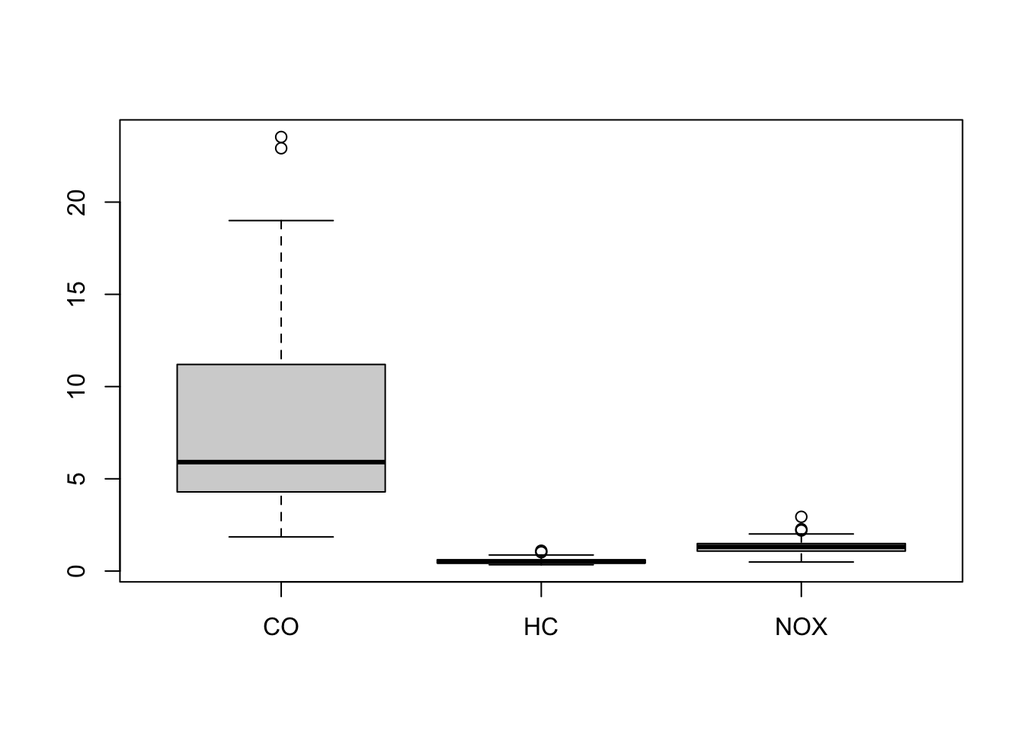

```r
boxplot(engine)
```

The boxplots suggests a few outliers at the top end of each scale.

```r
engine[engine$NOX>2.5,]
```

```
##      CO   HC  NOX
## 39 4.29 0.52 2.94
```

```r
engine[engine$CO>20,]
```

```
##       CO   HC  NOX
## 34 23.53 1.02 0.86
## 35 22.92 1.10 0.57
```

```r
engine[engine$HC>1,]
```

```
##       CO   HC  NOX
## 34 23.53 1.02 0.86
## 35 22.92 1.10 0.57
```

Outliers are identified as cases 39 (for NOX) and 34, 35 (for CO).

We are now ready to create a vector of colours to assign

```r
colours <- scales::alpha(rep('black', length=46 ),0.5) ## transparent black for all points
colours[39] <- 'red' ## NOX outlier will be solid red
colours[c(34,35)] <- 'blue' ## CO outliers will be solid blue
```

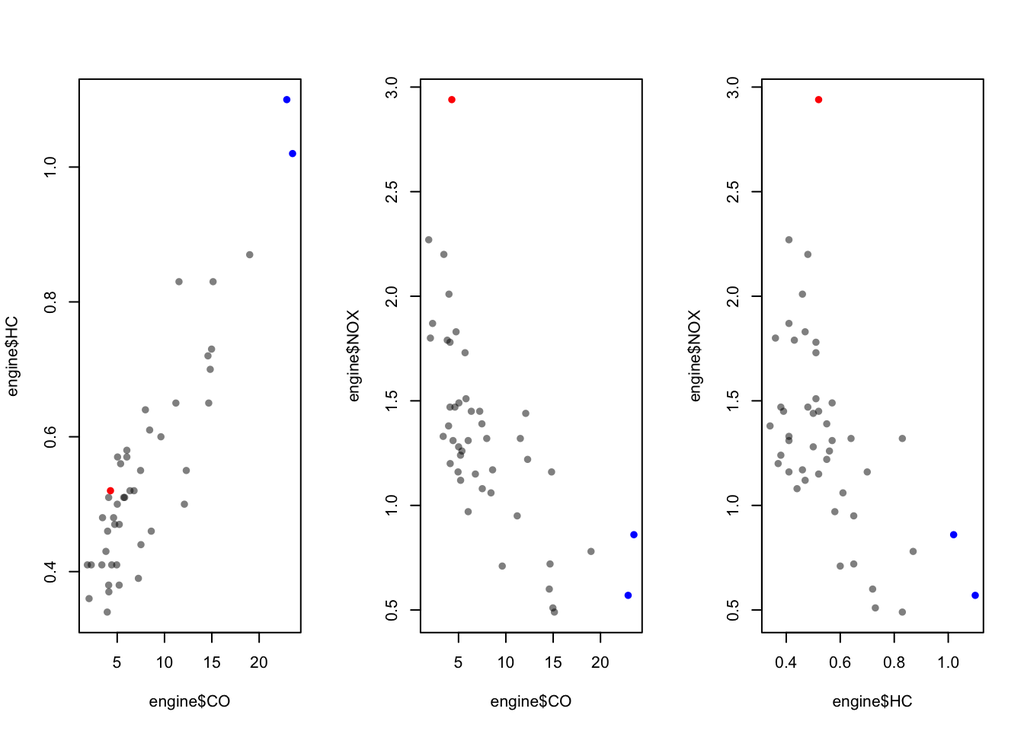

```r
par(mfrow=c(1,3)) ## redraw plots with new colours
plot(x=engine$CO, y=engine$HC, col=colours, pch=16)
plot(x=engine$CO, y=engine$NOX, col=colours, pch=16)
plot(x=engine$HC, y=engine$NOX, col=colours, pch=16)
```

```r
## now we can see that the outliers on CO are also the two largest values on HC
```

## Challenge

1. Type `data(airquality)` to load the built-in airquality data set
2. Produce a boxplot of the variables `Ozone` and `Wind`. How many outliers are there?
3. Check which observations correspond to these outliers and answer the question again: how many outliers? (caution! The variable `Ozone` has some missing data and the code above might need to be modified)
4. Produce a scatterplot of the two variables where the outliers are highlighted (by colour, as above or in other ways)

**Click for solution**

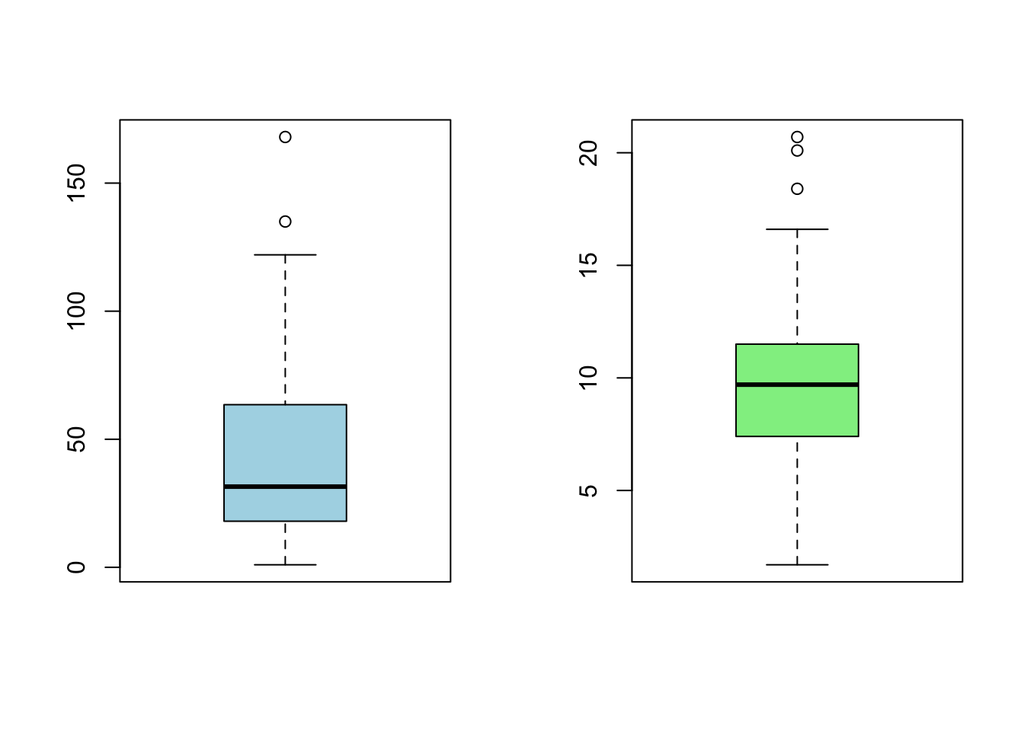

```r
data(airquality)

par(mfrow=c(1,2))
boxplot(airquality$Ozone, col = "lightblue")

boxplot(airquality$Wind, col = "lightgreen")
```

```r
airquality[!is.na(airquality$Ozone) & airquality$Ozone > 120, ]
```

```
##     Ozone Solar.R Wind Temp Month Day
## 62    135     269  4.1   84     7   1
## 99    122     255  4.0   89     8   7
## 117   168     238  3.4   81     8  25
```

```r
airquality[airquality$Wind>20,]
```

```
##    Ozone Solar.R Wind Temp Month Day
## 9      8      19 20.1   61     5   9
## 48    37     284 20.7   72     6  17
```

```r
colours <- scales::alpha(rep('black',length=153),0.5) ## transparent black for all points
colours[c(62, 99, 117)] <- 'red' ## NOX outlier will be solid red
colours[c(9,48)] <- 'blue' ## CO outliers will be solid blue
```

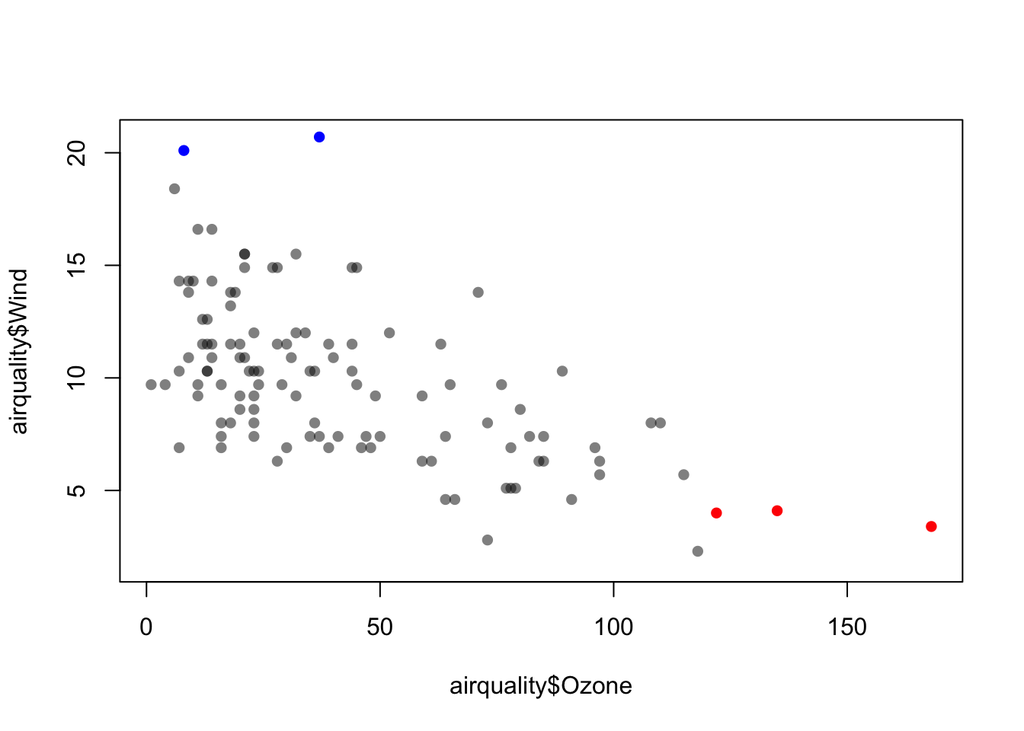

```r
plot(x=airquality$Ozone, y=airquality$Wind, col=colours, pch=16)
```